# Reproducible Research: Peer Assessment 1

## Loading and preprocessing the data

The following code chunk reads the data stored inside the *zip* file, formatted as a typical CSV. The file itself should be packed together with this document, so all we have to do is unpack them and read.

```r
raw_data <- read.csv(unz("activity.zip", "activity.csv"))
str(raw_data)
```

```
## 'data.frame':    17568 obs. of  3 variables:
##  $ steps   : int  NA NA NA NA NA NA NA NA NA NA ...
##  $ date    : Factor w/ 61 levels "2012-10-01","2012-10-02",..: 1 1 1 1 1 1 1 1 1 1 ...
##  $ interval: int  0 5 10 15 20 25 30 35 40 45 ...
```

From this summary one can immediately notice that the column *steps* has missing data, which needs to be handled later. Also, the date has been handled as *factors*, which can be fixed using the following code:

```r
raw_data$date <- as.Date(raw_data$date, format="%Y-%m-%d")
str(raw_data)
```

```
## 'data.frame':    17568 obs. of  3 variables:
##  $ steps   : int  NA NA NA NA NA NA NA NA NA NA ...
##  $ date    : Date, format: "2012-10-01" "2012-10-01" ...
##  $ interval: int  0 5 10 15 20 25 30 35 40 45 ...
```

We’ll be using the following libraries throughout out analysis.

```r
suppressWarnings(library(ggplot2))
```

## What is mean total number of steps taken per day?

The raw data has the number of steps taken at regular intervals of 5 minutes. Our first analysis is to estimate the mean total number of steps taken per day. With such goal in mind, the first step is to prepare the data by summing the number of steps on each day and create a histogram on how frequently the sample individual takes a certain number of steps in a single day.

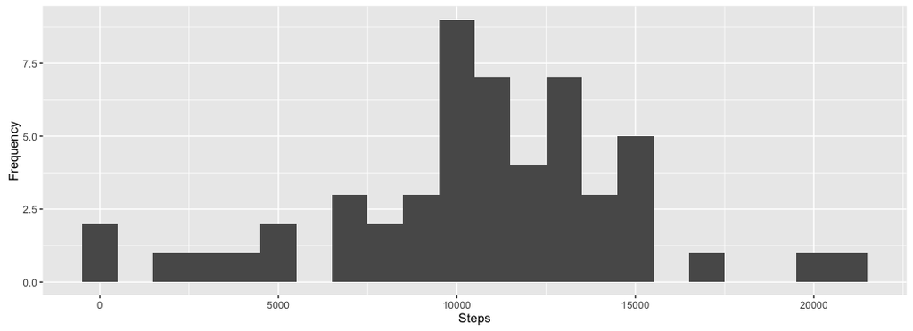

```r
steps_per_day <- aggregate(steps ~ date, raw_data, sum)

binwidth <- 1000
ggplot(steps_per_day, aes(steps)) +
    geom_histogram(binwidth = binwidth) +
    xlab("Steps") + ylab("Frequency")
```

Then we extract the mean and the median of steps taken per day, ignoring the missing values in the process.

```r
mean(steps_per_day$steps, na.rm = T)
```

```
## [1] 10766.19
```

```r
median(steps_per_day$steps, na.rm = T)
```

```
## [1] 10765
```

## What is the average daily activity pattern?

Another way to analyze the raw data is to check the activity pattern by averaging the number of steps taken on each 5-minute interval across all days.

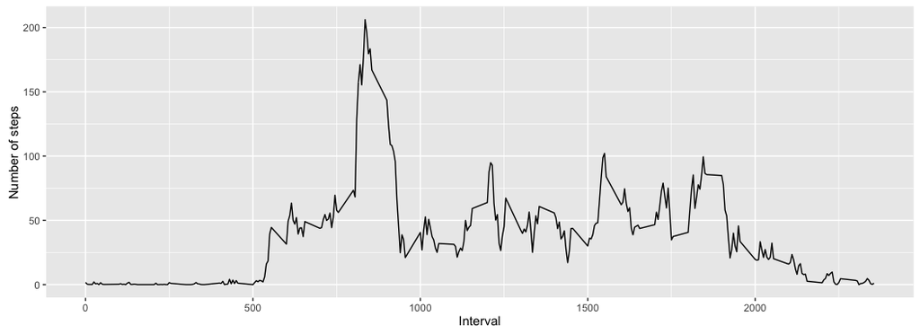

```r
steps_per_interval <- aggregate(steps ~ interval, raw_data, mean)
ggplot(aes(x=interval, y=steps), data = steps_per_interval) +
    geom_line(stat = 'identity', position = position_dodge(width=1)) +
    xlab("Interval") + ylab("Number of steps")
```

Then, by using this code:

```r
max_steps_index <- which.max(steps_per_interval$steps)
max_steps_interval <- steps_per_interval$interval[max_steps_index]
max_steps_value <- steps_per_interval$steps[max_steps_index]
```

We can see that, on average, the highest number of steps taken is 206.1698113 on the 835th interval.

**Bonus:** Another way to view the same data is to plot the whole data along the mean:

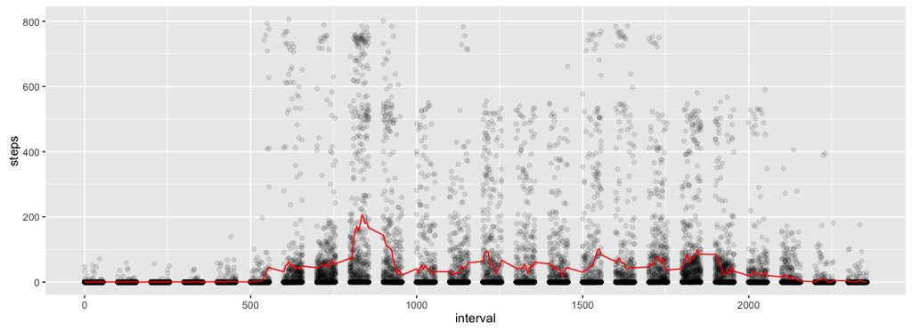

```r
ggplot(aes(x=interval, y=steps), data = raw_data) +
    geom_point(color="black", alpha = 0.1, na.rm = T) +
    stat_summary(aes(y = steps), fun.y=mean, colour="red", geom="line", na.rm = T)
```

## Imputing missing values

As noted before, there are some intervals whose number of steps is missing. Using the following code:

```r
sum(is.na(raw_data$steps))
```

```
## [1] 2304
```

We can see that there are 2304 missing values out of 17568 rows, which makes up for 13.1147541% of the whole dataset, which can make the data biased to the moments the measurements were being taken, particularly if the probability of having missing data is uneven across the intervals.

In order to minimize the effects of those missing values, we can replace them with the mean of the corresponding interval.

```r
steps_per_interval_arr <- tapply(raw_data$steps, raw_data$interval, mean, na.rm = T)

## Get the row indices whose steps is NA
indx <- which(is.na(raw_data$steps), arr.ind=TRUE)

## Replace those rows' values with the mean of their corresponding interval
filtered_data             <- raw_data
intervals_for_nas         <- as.character(filtered_data$interval[indx])
filtered_data$steps[indx] <- steps_per_interval_arr[intervals_for_nas]
```

Replicating the code from the first analysis, we compare both histograms and see if it any different from the original one. The dark red histogram is the original one while the light red is the addition caused by filling the missing values.

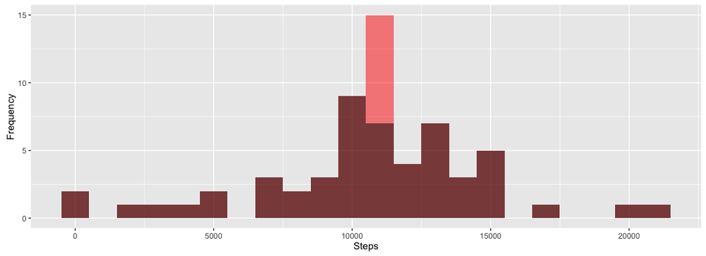

```r
steps_per_day_new    <- aggregate(steps ~ date, filtered_data, sum)
steps_per_day_new$na <- F

steps_per_day_old    <- steps_per_day
steps_per_day_old$na <- T

steps_per_day_comparison <- rbind(steps_per_day_new, steps_per_day_old)

ggplot(steps_per_day_comparison, aes(steps)) +
    geom_histogram(data=steps_per_day_new, fill = "red", alpha = 0.5, binwidth = binwidth) +
    geom_histogram(data=steps_per_day_old, fill = "black", alpha = 0.5, binwidth = binwidth) +
    xlab("Steps") + ylab("Frequency")
```

It is possible to notice that the new distribution is mostly the same with one major difference: the frequency around the mean has greatly increased. Under the hypothesis that the the probability of having missing data has no correlation to the intervals, this is the expected behavior, as replacing them with the mean number of steps of the interval should increase the frequency around the mean, and less so everywhere else.

In terms of numeric values, changes on the mean and median have been minimal as well:

```r
mean(steps_per_day_new$steps, na.rm = T)
```

```
## [1] 10766.19
```

```r
median(steps_per_day_new$steps, na.rm = T)
```

```
## [1] 10766.19
```

## Are there differences in activity patterns between weekdays and weekends?

Finally, we check is there is a difference between the individual’s behavior on weekdays and weekends. In order to do that, first we create new columns holding information about the type of weekday.

```r
filtered_data$weekday    <- weekdays(filtered_data$date)
filtered_data$is.weekend <- as.factor(c("weekday", "weekend"))

weekend_indices <- filtered_data$weekday == "Sunday" | filtered_data$weekday == "Saturday"
weekday_indices <- filtered_data$weekday != "Sunday" & filtered_data$weekday != "Saturday"

filtered_data$is.weekend[weekday_indices] <- factor("weekday")
filtered_data$is.weekend[weekend_indices] <- factor("weekend")

str(raw_data)
```

```
## 'data.frame':    17568 obs. of  3 variables:
##  $ steps   : int  NA NA NA NA NA NA NA NA NA NA ...
##  $ date    : Date, format: "2012-10-01" "2012-10-01" ...
##  $ interval: int  0 5 10 15 20 25 30 35 40 45 ...
```

Now we calculate the mean number of steps based on both *interval* and whether the date is a weekend or not and plot a chart to compare them.

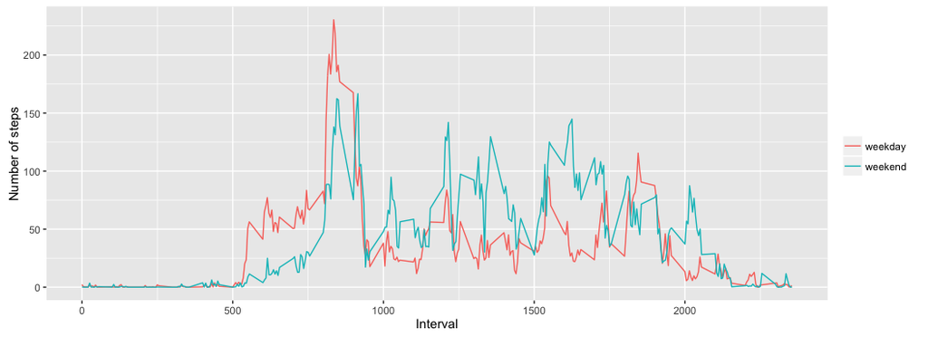

```r
steps_per_interval <- aggregate(steps ~ interval + is.weekend, filtered_data, mean)
ggplot(aes(x=interval, y=steps, color=is.weekend), data = steps_per_interval) +
    geom_line(stat = 'identity', position = position_dodge(width=1)) +
    xlab("Interval") + ylab("Number of steps") + theme(legend.title=element_blank())
```

There are some obvious changes in behavior: starting from the earlier intervals, it seems that the sample individual wakes up much later on weekends, but the amount of steps taken is more evenly distributed while on weekdays, he/she walks much more soon after waking up and by the end of the day - probably the result from commuting from/to work or school. Also, it seems that the hour he/she goes to sleep does not differ greatly.

Finally, on average, the said individual seems to walk less on weekdays, which can be a hint about his/her occupation. It is unlikely to be anything that requires a lot of physical work or moving around, though further inferences without more information may be speculative at best.